# Analyzing Inequalities in the U.S Prison System

## Comparing Jail Populations Between Males and Females in 2010-2018

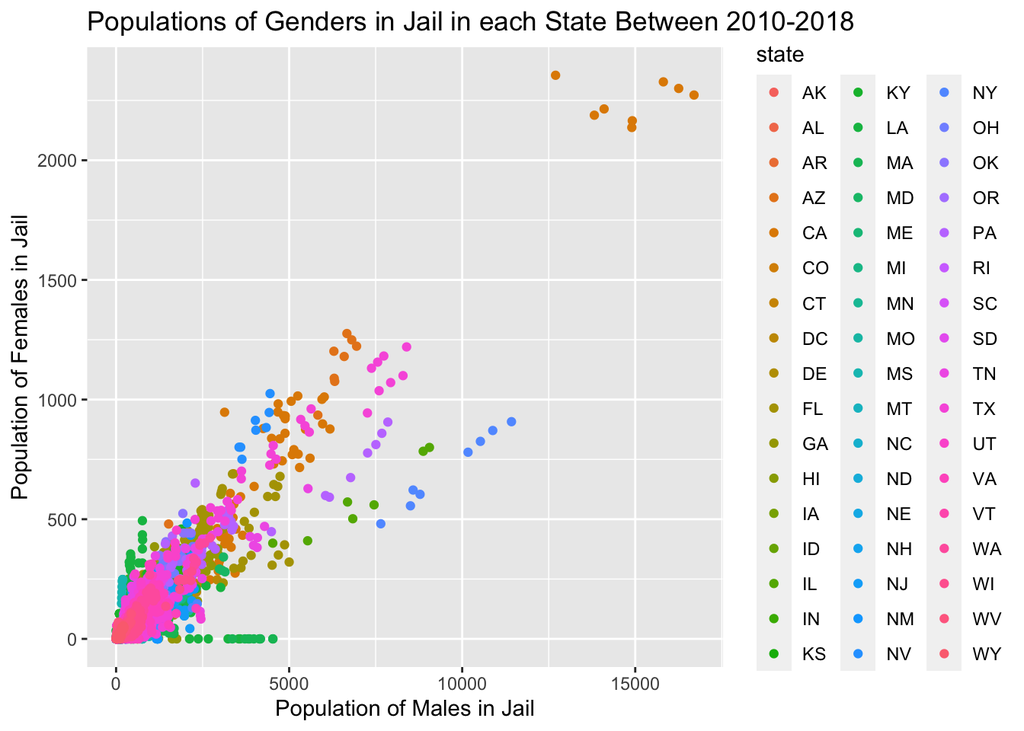

*Figure 3.* Comparing different genders and their incarceration in each state between 2010- 2018.

## Analyzing the Number of People Incarcerated by ICE

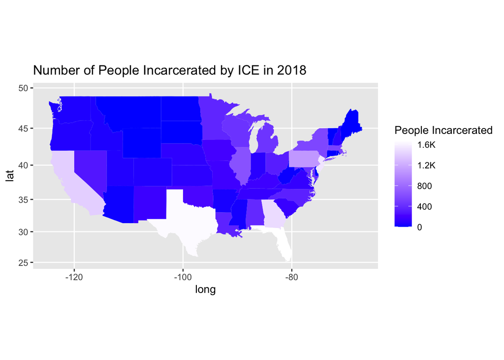

*Figure 4.* This map depicts the number of people incarcerated by ICE in 2018.

The U.S Immigration and Customs Enforcement (ICE) regulates immigration status in the U.S including enforcement of legal immigration. Some people immigrate to the U.S in order to find opportunities to grow or seek resources that are not available in their countries. Detainment of people by ICE has been a controversial topic because of unethical deportation of people to go back to their country. This raises the question, “In what places in the U.S is where the most people are incarcerated by ICE?” As seen in the map, Texas and Florida have the highest amounts of people who were incarcerated by ICE in 2018. Overall, these states have a disproportionate amount of incarceration compared to the rest of the U.S.